# Lab 9. Ecological integrity.

Spatial autocorrelation and Moran’s I.

Author

Travis Belote

# Background

“A thing is right when it tends to preserve the **integrity**, stability and beauty of the biotic community. It is wrong when it tends otherwise.” - Aldo Leopold

The concept of ecological integrity is pervasive in global conservation targets and U.S. federal policy. The first two targets of the Global Biodiversity Framework outline the importance of protecting “ecosystems of high ecological integrity”. The Clean Water Act, National Wildlife Refuge System Improvement Act of 1997, U.S. Forest Service’s 2012 Planning Rule, and the Bureau of Land Management’s (BLM) Fundamentals of Rangeland Health, among other laws and regulations reference the importance of maintaining or restoring ecological integrity.

As an example, the Forest Service’s 2012 Planning Rule requires that forest plans “must include plan components… to maintain or restore the ecological integrity of terrestrial and aquatic ecosystems.” Ecological integrity is defined here as “the quality or condition of an ecosystem when its dominant ecological characteristics (for example, **composition**, **structure**, **function**, connectivity, and species composition and diversity) occur within the natural range of variation and can withstand and recover from most perturbations imposed by natural environmental dynamics or human influence.”

[figure not shown]

Wildlife Conservation Society’s diagram of ecological integrity focuses on composition, structure, and function of ecosystems and landscapes.

The concept of ecological integrity is similar to the concept of ecological intactness. Often, integrity and intactness are used synonymously. One of the requirements of BLM’s Public Lands Rule is to “Protect the most intact, functioning landscapes.”

Clearly, policy makers understand that “integrity” is important to maintain or restore, and various definitions of integrity have been presented. However, there is no “integrity-meter” that measures an unambiguous attribute of landscapes. Most scholars understand integrity to be assessed using multiple criteria.

In the last several years numerous efforts have used spatial data on roads, land cover, light pollution, transmission lines, and other mapped features that represent a degree of human modification as a composite index. The Human Footprint, global map of human modification, and other spatial data have been produced that assume that land use and development represent stressors that can alter the ecological composition, structure, and function (i.e., ecological integrity).

Image below illustrates how multiple datasets are combined to map the Human Footprint, which has been associated with ecological integrity. Figure from [this paper](https://www.sciencedirect.com/science/article/pii/S2590332219300715).

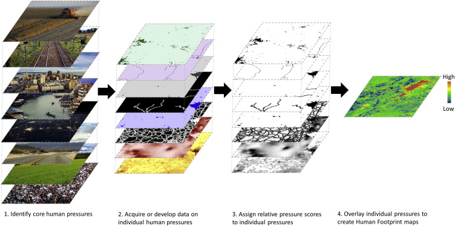

Here, we will evaluate the human modification dataset that has been used to map lands of high integrity (i.e., intact landscapes). We will explore the spatial patterns of these datasets using spatial statistics (e.g., Moran’s I) and investigate how ecological integrity varies with topography and among regions of Montana, Idaho, and Wyoming. Spatial patterns in human modification and ecological integrity may tell us whether the underlying patterns are random or clumped in a similar way to topography, soils, or other factors that influence where humans develop lands, build roads, or otherwise modify landscapes. We will only scratch the surface here. The goals of this lab are (1) to introduce you to the multiple criteria that have been used to measure and map ecological integrity and (2) to demonstrate how spatial statistics can be used with these kinds of data.

## Theobald’s human modification data and ecological integrity

A widely used dataset to represent ecological integrity is David Theobald and colleagues’ map of [human modification](https://www.nature.com/articles/s41597-025-04892-2). Theobald and colleagues combined mapped features that represent ecological stressors including land cover conversion, roads, mining activity, human population density, and other criteria that represent ways that humans alter natural ecosystems. The combination of these criteria has been used as a composite map of human modification or the inverse, ecological integrity. The data have been used to map the Earth’s remaining [intact landscapes](https://scholar.law.colorado.edu/cgi/viewcontent.cgi?article=1560&context=celj) (wildlands or wilderness), as the basis for [connectivity modeling](https://link.springer.com/article/10.1007/s10980-022-01530-9), and as a general map of [ecological integrity](https://link.springer.com/article/10.1007/s10980-013-9941-6).

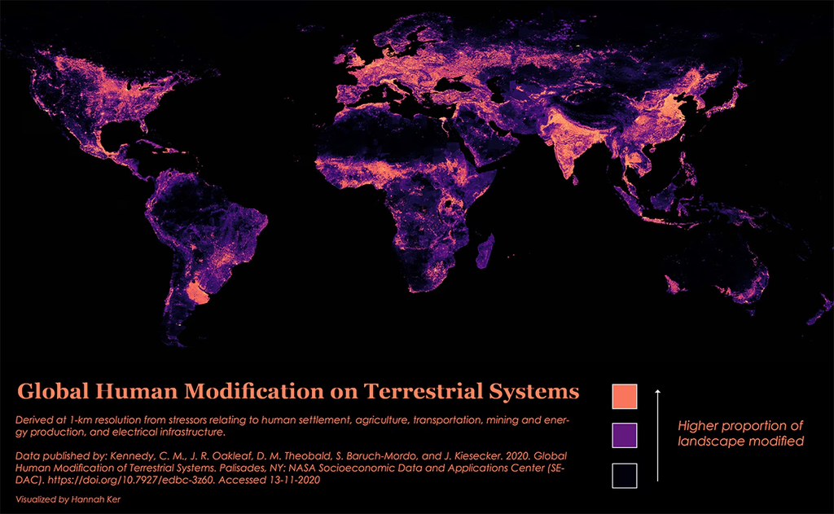

We will explore global and local Moran’s I using the composite map of ecological integrity. This approach will be used to ask questions such as “how clumped are lands of high ecological integrity across Montana, Idaho, and Wyoming based on the different features that may disrupt ecological integrity?”

```r
# Load packages (install if you need to)
library(terra)
library(sf)
library(mapview)
library(pals)
library(viridis)
library(tidyverse)
library(ggridges)
library(ncf)
```

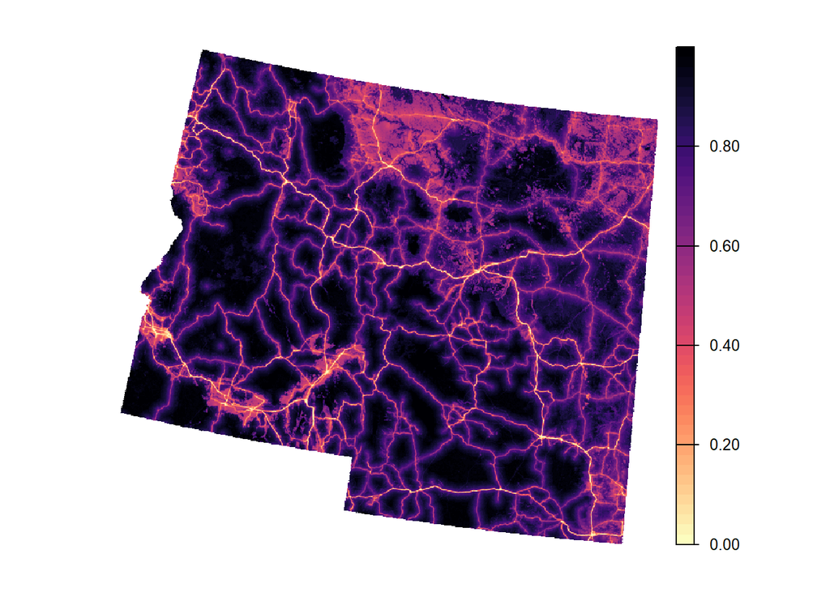

```r
# Bring in human modification-based map of ecological integrity
ei <- rast("Z:/Teaching/BIOE515_LandEcol_Man_Fall2025/Labs/Lab 9/hm_MTIDWY.tif")

# Look at a map of ecological integrity (i.e, the oppposite of human modification)
plot(ei, col = rev(magma(50)), axes = F)
```

### Assessing ecological integrity among ecoregions using “ridgeline” plots

Before we explore the spatial autocorrelation of ecological integrity and consider what these patterns mean, let’s summarize the patterns among ecoregions of Montana, Idaho, and Wyoming. First, we’ll bring in the ecoregion polygons, `rasterize` them, stack the ecoregions with the ecological integrity, turn the stack into a dataframe, and plot kernel density plots (i.e., “smoothed” histograms) for each ecoregion (in a visualization sometimes called “ridgeline” plots).

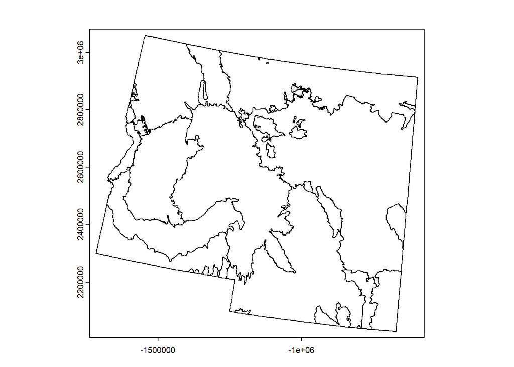

```r
# read in the ecoregions for Montana, Idaho, and Wyoming
ecoregions <- vect("Z:/Teaching/BIOE515_LandEcol_Man_Fall2025/Labs/Lab 9/MTIDWY_ecoregions/ecoregions_MTIDWY.shp")

# look at the map of ecoregions
plot(ecoregions)
```

```r
# Look at the names. We will want this when we rasterize the polygons
names(ecoregions)
```

```
 [1] "US_L3CODE"  "US_L3NAME"  "NA_L3CODE"  "NA_L3NAME"  "NA_L2CODE"
 [6] "NA_L2NAME"  "NA_L1CODE"  "NA_L1NAME"  "L3_KEY"     "L2_KEY"
[11] "L1_KEY"     "Shape_Leng" "Shape_Area" "FID"
```

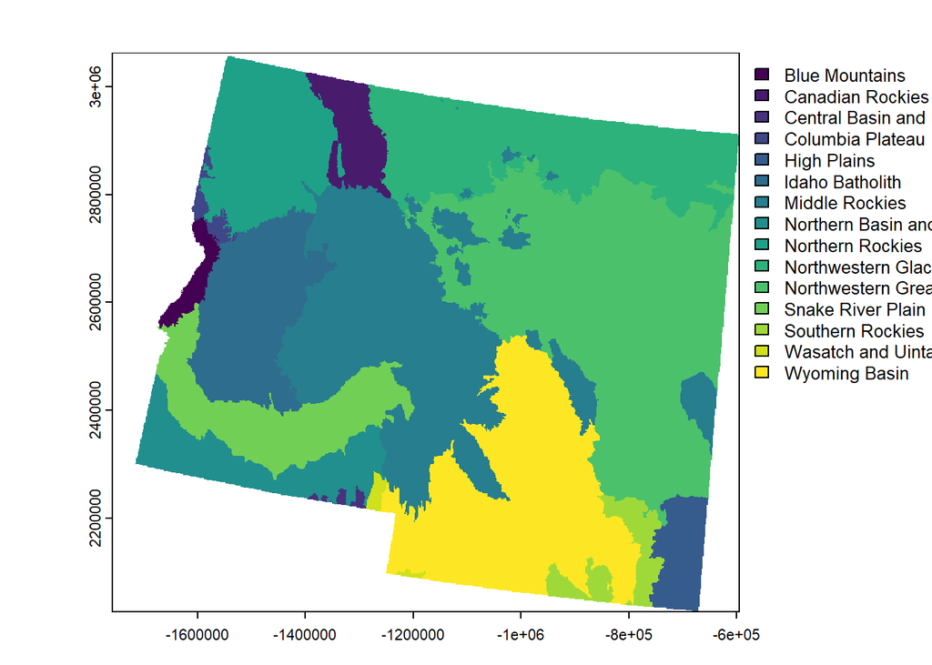

```r
# Turn the ecoregion polygons into a raster using rasterize
# make the cell size, crs, and extent match the ecological integrity ("ei") data
# and assign the pixels the ecoregion names in the field "US_L3NAME"
ecoRaster <- ecoregions %>% rasterize(ei, field = "US_L3NAME")

# Look at this map
plot(ecoRaster)
```

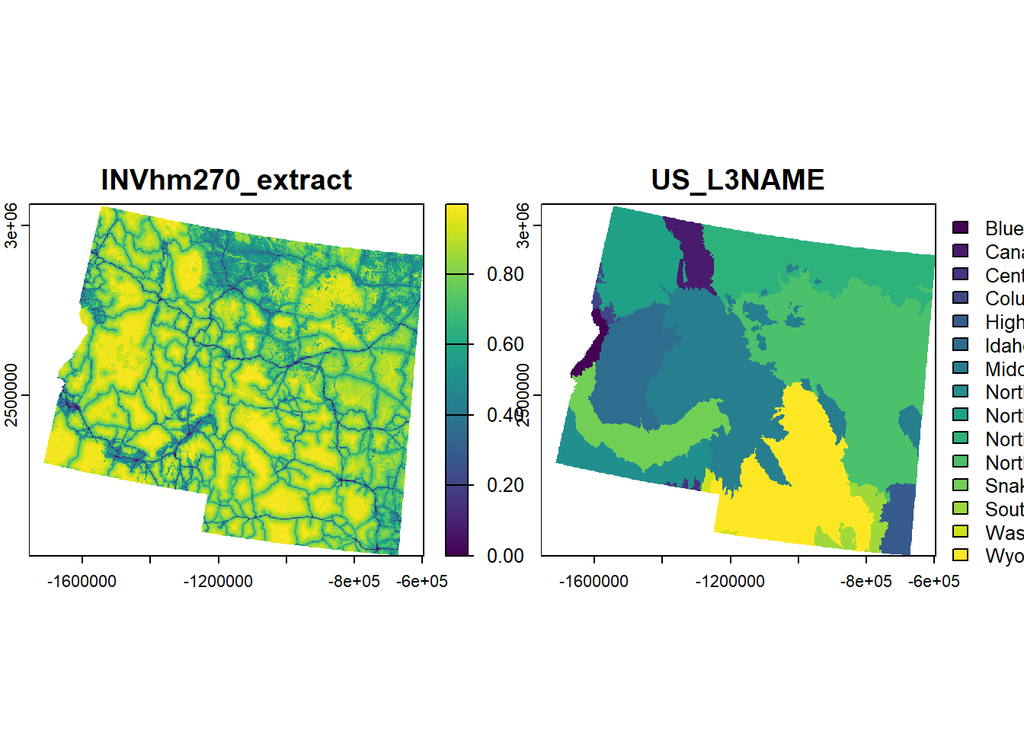

```r
# Stack this rasterized ecoregions with the ecological integrity data
ei_ecoregion <- c(ei, ecoRaster)

# Look at the maps
plot(ei_ecoregion)
```

```r
# Let's rename the layers in the stack
names(ei_ecoregion) <- c("ei", "ecoregion")

# We will turn these two rasters into a dataframe keeping the coordinates (xy = T)
ei_ecoregionDF <- as.data.frame(ei_ecoregion, xy = TRUE)

# look at the top of the dataframe
head(ei_ecoregionDF)
```

```
            x       y        ei        ecoregion
3702 -1545473 3059679 0.9815145 Northern Rockies
3703 -1544473 3059679 0.9818787             <NA>
4865 -1545473 3058679 0.9819241 Northern Rockies
4866 -1544473 3058679 0.9821137 Northern Rockies
4867 -1543473 3058679 0.9809589 Northern Rockies
4868 -1542473 3058679 0.9743989 Northern Rockies
```

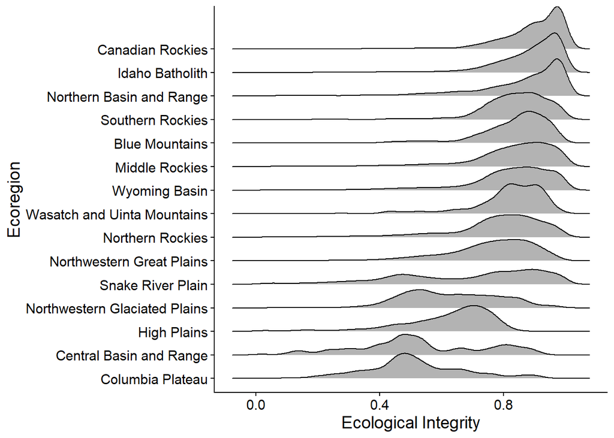

```r
# We will use some special plotting features in "ggridges" for this plot
ei_ecoregionDF %>% drop_na() %>% group_by(ecoregion) %>%
  sample_frac(0.1) %>% ungroup() %>%
  ggplot(aes(x = ei, y = fct_reorder(factor(ecoregion), ei, .fun = mean))) +
  geom_density_ridges() +
  xlab("Ecological Integrity") + ylab("Ecoregion")+
  guides(fill = FALSE)+
  theme_classic() + theme(text = element_text(size = 14))
```

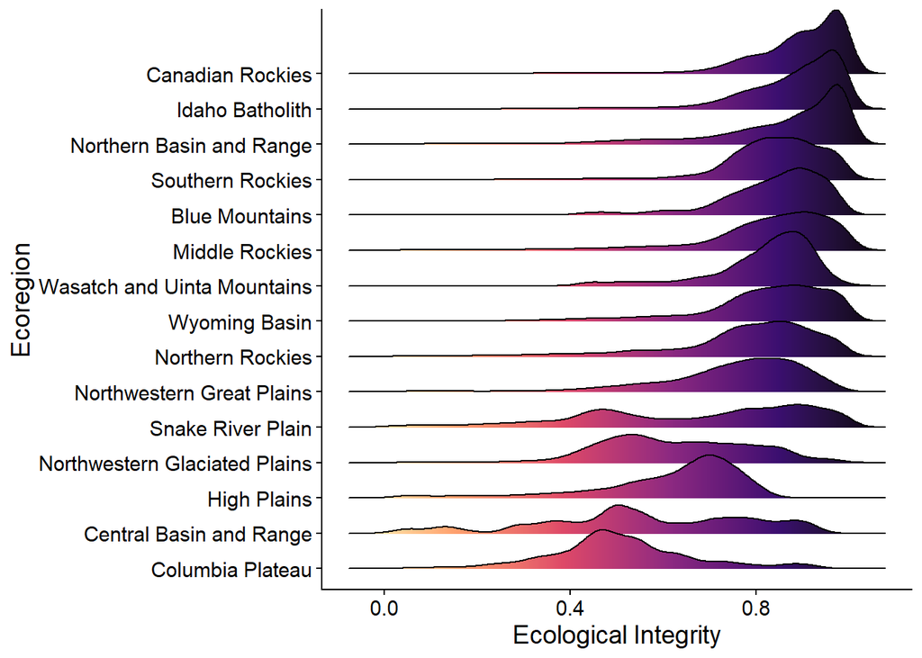

```r
# Let's use a color scheme that we could match with our maps
ei_ecoregionDF %>% drop_na() %>% group_by(ecoregion) %>%
  sample_frac(0.1) %>% ungroup() %>%
  ggplot(aes(x = ei, y = fct_reorder(factor(ecoregion), ei, .fun = mean))) +
  geom_density_ridges_gradient(aes(fill = after_stat(x))) +
  scale_fill_viridis_c(option = "magma", direction = -1) +
  xlab("Ecological Integrity") + ylab("Ecoregion")+
  guides(fill = FALSE)+
  theme_classic() + theme(text = element_text(size = 14))
```

Look at the ridgeline plots of ecological integrity for each ecoregion. Which ecoregions have the highest ecological integrity? Why?

We will now explore the geographic distribution of ecological integrity using spatial statistics.

### Spatial autocorrelation in ecological integrity

One of the first laws of geography is that things closer together tend to be more alike than things further apart. I’m paraphrasing Tobler’s Law. In ecology, we say that things we measure are often spatially correlated, or that there is spatial autocorrelation in the data (variables are correlated with themselves across geographic space). Observing and quantifying this autocorrelation can reveal important spatial patterns and processes (e.g., species dispersal and colonization) and may also be essential for adhering to the statistical assumption that samples are independent. In other words, if you sample in a way where a variable shows strong spatial autocorrelation, you may not be able to count those observations as truly independent. This can mess up our inference when conducting hypothesis testing and must be addressed. Here, we will focus on assessing spatial autocorrelation to quantify spatial patterns in continuous data on ecological integrity. Assessing these patterns may provide insights into landscapes that maintain their integrity and those that have impaired integrity.

We will use Moran’s I to do this. Put simply, Moran’s I is analogous to a correlation coefficient assessing how one variable is correlated with itself across geographic space. In fact, the formula for Moran’s I is very similar to the formula to calculate a correlation coefficient and can be interpreted similarly. The higher Moran’s I, the stronger the spatial autocorrelation. Take, for example, the simulated landscapes below. I have included Moran’s I above each map. The closer the patterns become to random (i.e., uncorrelated) the lower Moran’s I is. These values are called “global” Moran’s I and provide one number to quantify the entire landscape.

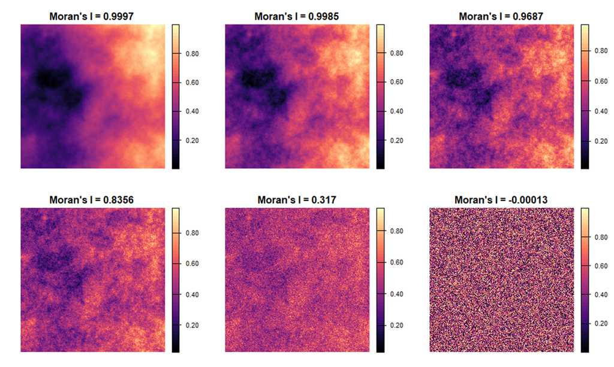

You can also calculate “local” Moran’s I and assess how the spatial autocorrelation changes with distance between observations. We can map local spatial correlation like below. Higher local autocorrelation is in yellow.

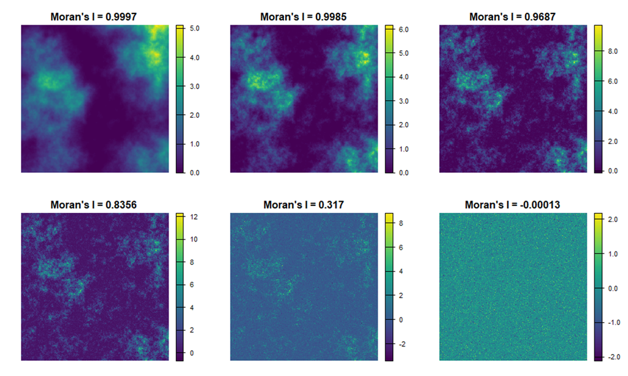

And we can plot how autocorrelation changes with distance using plots known as correlograms. Correlograms are closely related to “variograms” or “semivariograms”, but show the opposite patterns (i.e., how dissimilarity increases with distance). Correlograms can be useful in understanding the spatial scale driving a process, helping to decide on an appropriate grain or resolution to use in predictive modeling, aiding a field study to avoid spatial autocorrelation (i.e., how far apart should you put plots so that data are not spatial autocorrelated?). Here, we will use correlograms to understand the spatial extent of patterns in ecological integrity. The examples below show the correlograms associated with the maps above. Again, as the patterns become more random the correlation of observation closer together approaches 0.

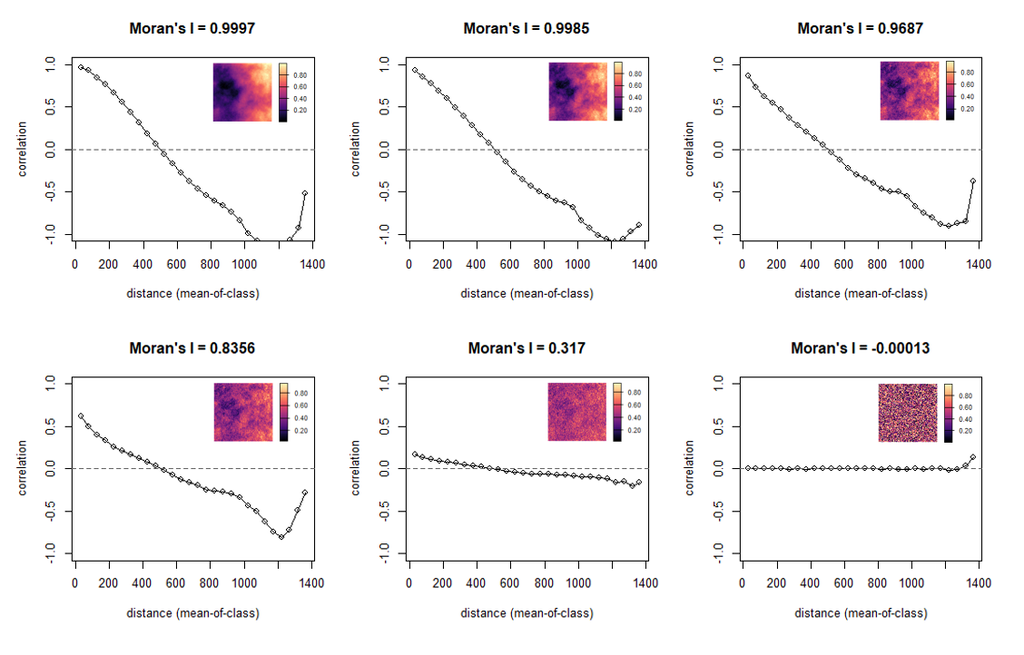

We will first calculate the global Moran’s I, which is quite easy in R. The package `terra` has a function called `autocor` that allows you to do this.

Then, we will calculate and map local Moran’s I.

```r
# Calculate global Moran's I for entire raster
ei_global_I <- autocor(ei, global = TRUE, method = "moran")
ei_global_I
```

```
INVhm270_extract
       0.9332348
```

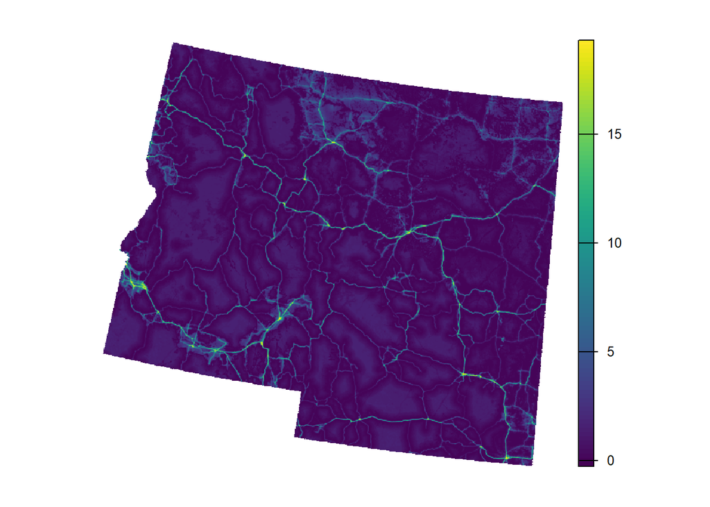

```r
# Calculate Local Moran's I
ei_local_I <- autocor(ei, global = FALSE, method = "moran")

# Look at the map of local Moran's I
plot(ei_local_I, axes = F)
```

Now, let’s create a correlogram to investigate how spatial autocorrelation varies with distance, as I have done above for the simulated landscapes.

```r
set.seed(3950)
# We need to make the raster a dataframe
eidf <- ei %>% as.data.frame(xy = T) %>% sample_n(1000)

# adjust the names
names(eidf) <- c("x", "y", "ei")

# run the correlogram from the package ncf
# increment = 25000 (meters) is the distance "bins" used to calculate
# autocorrelation at different distances.
cor_int <- ncf::correlog(x = eidf$x, y = eidf$y, z = eidf$ei,
                         increment = 25000, resamp = 0, na.rm = TRUE)

# look at the output called "cor_int"
cor_int
```

```
$n
    1     2     3     4     5     6     7     8     9    10    11    12    13
 1104  3245  5180  6827  8455 10126 11176 12402 13432 14702 15573 16357 16940
   14    15    16    17    18    19    20    21    22    23    24    25    26
17547 17888 18263 18452 18187 18592 18367 17866 17852 16971 16657 15970 15631
   27    28    29    30    31    32    33    34    35    36    37    38    39
14836 13961 13012 12206 11378 10352  9659  8810  7995  6836  5797  4930  4191
   40    41    42    43    44    45    46    47    48    49    50    51    52
 3283  2459  1816  1277   944   692   479   342   201   127    92    44    18
   53
    1

$mean.of.class
         1          2          3          4          5          6          7
  16491.92   38681.19   63256.82   87910.33  112727.42  137872.93  162626.92
         8          9         10         11         12         13         14
 187634.81  212641.76  237676.88  262549.95  287511.31  312439.38  337591.23
        15         16         17         18         19         20         21
 362543.72  387457.27  412440.10  437446.86  462510.17  487449.32  512374.94
        22         23         24         25         26         27         28
 537466.94  562395.47  587402.91  612489.06  637394.40  662424.51  687345.22
        29         30         31         32         33         34         35
 712324.42  737289.96  762254.35  787288.03  812335.51  837316.46  862229.42
        36         37         38         39         40         41         42
 887219.72  912137.53  936868.09  962273.30  986886.85 1011935.92 1036910.60
        43         44         45         46         47         48         49
1061640.15 1086888.45 1111845.39 1136732.94 1162055.76 1185552.22 1212116.32
        50         51         52         53
1236759.01 1263332.49 1283509.86 1300389.17

$correlation
            1             2             3             4             5
 0.3444458685  0.1790701393  0.1121178328  0.0842828618  0.0605681675
            6             7             8             9            10
 0.0533616922  0.0457547941  0.0257871178  0.0064547356 -0.0035318521
           11            12            13            14            15
-0.0084579452  0.0081272843  0.0001941112  0.0002364264  0.0097910089
           16            17            18            19            20
-0.0045105907 -0.0125688366  0.0061867411  0.0127844584 -0.0195545223
           21            22            23            24            25
```

[output cut: 12 more lines]

```
-0.0264290979 -1.0016964911 -0.3151295023

$x.intercept
(Intercept)
   221495.7

$p
NULL

$call
[1] "ncf::correlog(x = eidf$x, y = eidf$y, z = eidf$ei, increment = 25000, "
[2] "    resamp = 0, na.rm = TRUE)"

attr(,"class")
[1] "correlog"
```

```r
# Notice some distances have VERY few observations!
```

Now, let’s produce the correlogram using the output we created above. The `type = "b"` and `pch = 19` are just graphing options (`type = b` is connecting dots with lines and `pch = 19` tells R we want our points to be filled circles. We’re also dividing the “mean of class” by 1000 so that the units are in kilometers and not meters. `abline` just adds a hashed line to the plot at 0, so there’s a clear indication of where we lose any spatial autocorrelation.

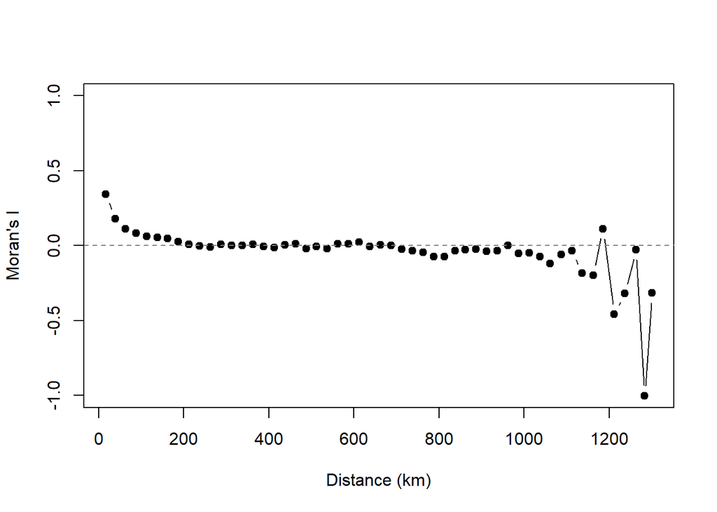

```r
# Plot the output of the correlogram using base R
# "mean of class" is the mean distances. Let's divide those by 1000 so that the
# units are in km and not meters
plot(cor_int$mean.of.class / 1000, cor_int$correlation,
  type = "b", pch = 19, ylim = c(-1,1),
  xlab = "Distance (km)", ylab = "Moran's I")
abline(h = 0, lty = 2, col = "grey50")
```

Look back at the map of ecological integrity as measured by Theobald’s human modification, and study the correlogram. What does the plot tell you about the spatial ‘clumpiness’ of areas of high human modification or high ecological integrity? What are the causes and consequences of these patterns?

Let’s bring in the inputs to human modification and evaluate the spatial autocorrelation in each of the criteria.

```r
# list of the files with the extension of "tif" and return the full file names.
ei_input_files <- list.files("Z:/DaveT/global/MTIDWY",
                             pattern = ".tif$", full.names = TRUE)
# look at these filenames.
ei_input_files
```

```
[1] "Z:/DaveT/global/MTIDWY/HMv20240801_2022s_AA_300_tif.tif"
[2] "Z:/DaveT/global/MTIDWY/HMv20240801_2022s_AG_300_tif.tif"
[3] "Z:/DaveT/global/MTIDWY/HMv20240801_2022s_BU_300_tif.tif"
[4] "Z:/DaveT/global/MTIDWY/HMv20240801_2022s_EX_300_tif.tif"
[5] "Z:/DaveT/global/MTIDWY/HMv20240801_2022s_FR_300_tif.tif"
[6] "Z:/DaveT/global/MTIDWY/HMv20240801_2022s_HI_300_tif.tif"
[7] "Z:/DaveT/global/MTIDWY/HMv20240801_2022s_NS_300_tif.tif"
[8] "Z:/DaveT/global/MTIDWY/HMv20240801_2022s_PO_300_tif.tif"
[9] "Z:/DaveT/global/MTIDWY/HMv20240801_2022s_TI_300_tif.tif"
```

```r
# Now, stack the rasters up.
ei_inputs <- rast(ei_input_files)
```

These inputs include two letter codes, which are described below. Look over this list and consider how these “threat types” might impact ecological integrity. Again, consider ecological integrity as a quality of ecosystems and landscapes related to the composition, structure, and function. How might each of these threats affect integrity and in what ways? What is missing?

| Code | Threat Type | Description |
| --- | --- | --- |
| **AA** | All threats combined | Composite index integrating all human modification pressures. |
| **AG** | Agriculture | Areas modified by crop cultivation, pasture, or other agricultural use. |
| **BU** | Built environments | Residential, commercial, and recreational development. |
| **EX** | Energy production and mining | Land modified for oil, gas, coal, wind, solar, or mineral extraction. |
| **FR** | Biological resource use | Areas affected by forestry, logging, or other extraction of biological resources. |
| **HI** | Human accessibility | Modification due to proximity to human access (e.g., roads, trails, settlements). |
| **NS** | Natural systems modification | Alterations of natural processes such as dams, water diversion, or fire suppression. |
| **PO** | Pollution | Areas influenced by chemical, nutrient, or other pollution sources. |
| **TI** | Transportation and service corridors | Roads, railways, powerlines, pipelines, and other linear infrastructure. |

Now, let’s look at the maps of each of these threats or stressors.

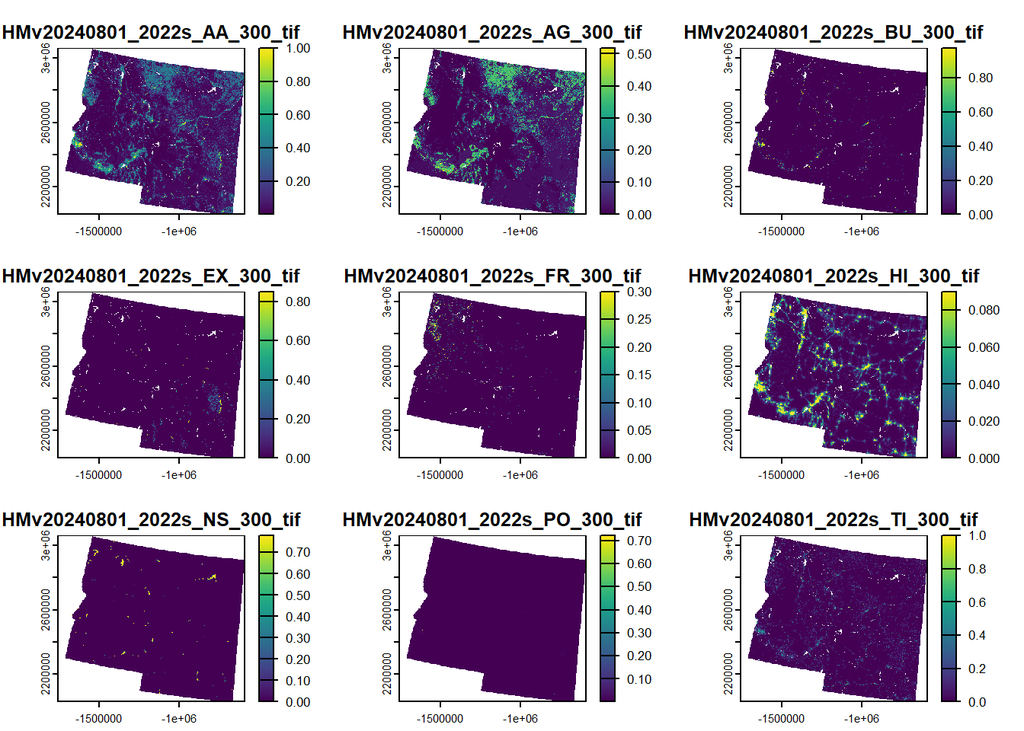

```r
# Look at the maps of the inputs to human modification
plot(ei_inputs)
```

**TASK 1 (20 points).**

Look at the patterns in the maps for the inputs to human modification. Re-run the global and local Moran’s I for **at least 3** of the inputs and produce the correlogram. Compare the values and maps of the three criteria in relationship to how (and why) humans modified lands and whether the modification is spatially aggregated or more randomly distributed. Compare your correlograms to the ones I created with the simulated landscapes above. What do you think the ecological consequences of these different patterns are for ecological integrity? Include the maps and plots in a multi-panel figure with a descriptive caption, report the global Moran’s I in the caption, and describe the patterns. Write up your results as an abstract for *Landscape Ecology*.

# Ecological integrity and topography.

Now, let’s investigate whether human modification and ecological integrity vary with topography, namely elevation and slope steepness. We will first bring in elevation, project it to match the human modification data, and calculate slope using the `terrain` function.

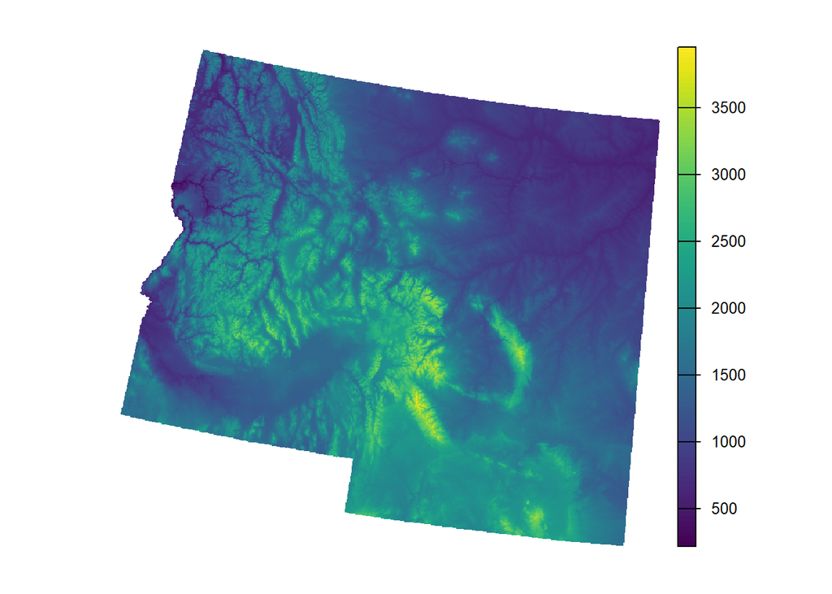

```r
# Bring in elevation data (a digital elevation model)
elv <- rast("Z:/Teaching/BIOE515_LandEcol_Man_Fall2025/Labs/Lab 9/elev_MTIDWY.tif")
# match the projection to the human modification data
elvPRJ <- project(elv, ei, method = "bilinear")

# Look at the elevation map, which is always pretty cool for this region.
plot(elvPRJ, axes = F)
```

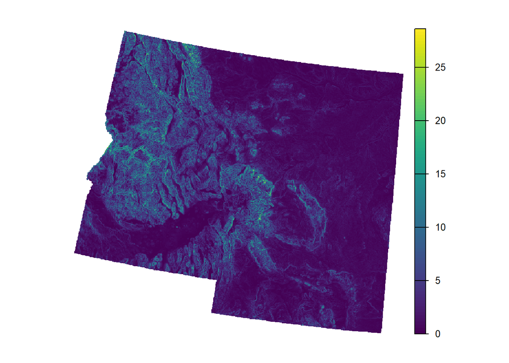

```r
# calculate the slope and plot it
slp <- terrain(elvPRJ, "slope")
plot(slp, axes = F)
```

Now, we will create a raster stack of ecological integrity, elevation, and slope. We will turn this raster stack into a dataframe, and use `ggplot` to investigate the relationship between elevation and slope and human modification.

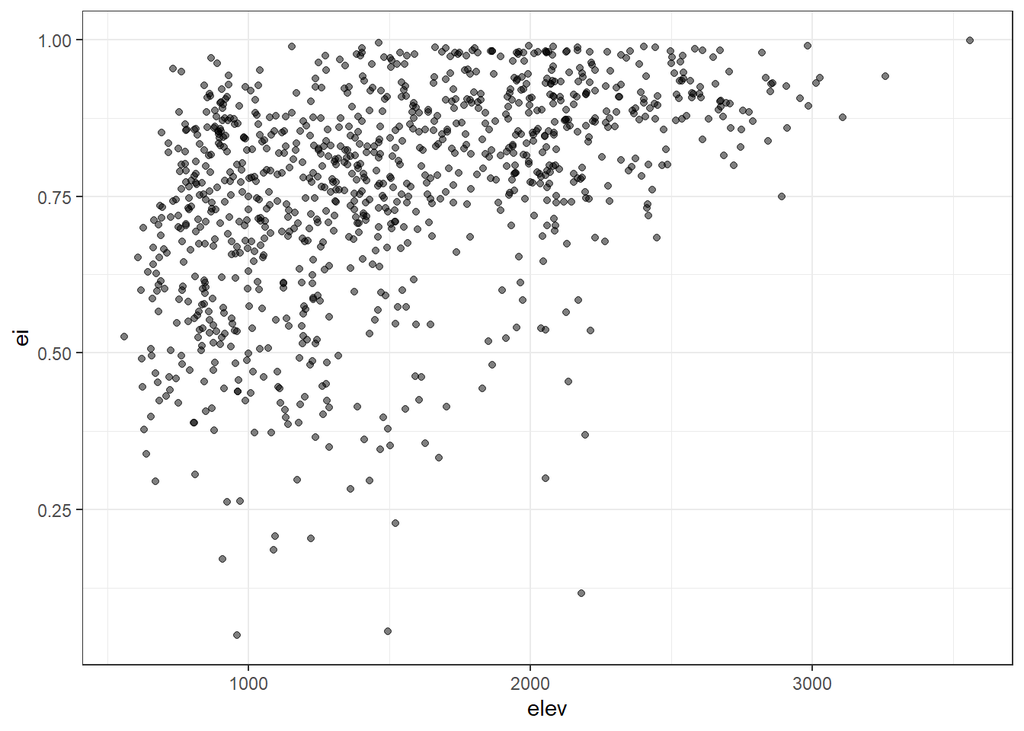

```r
# Use the Theobald hm data and stack with elevation and slope calculated above.
ei_topo <- c(ei, elvPRJ, slp)
ei_topoDF <- as.data.frame(ei_topo, xy = T) %>% sample_n(1000)
names(ei_topoDF) <- c("x", "y", "ei", "elev", "slope")

# create the plot of elevation and ecological integrity
ei_topoDF %>% ggplot(aes(x = elev, y = ei)) + geom_point(alpha = 0.5) + theme_bw()
```

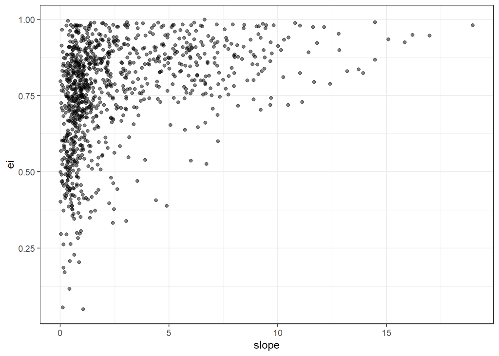

```r
# create the plot of slope steepness and ecological integrity
ei_topoDF %>% ggplot(aes(x = slope, y = ei)) + geom_point(alpha = 0.5) + theme_bw()
```

**TASK 2 (20 points).**

More rigorously explore the relationships between ecological integrity and topography (elevation and slope). What kind of analysis could you use for hypothesis testing here (hint: what did we use when the scatter plot looks like a piece of pie?)? Interpret the results. What is driving the patterns? What are the ecological and conservation consequences? Re-run the global and local Moran’s I and produce a correlogram of elevation. Compare patterns of spatial autocorrelation with those we produced for ecological integrity. Which patterns are more randomly distributed and which patterns are more spatially clumped? What are the causes and consequences of these patterns? Write up your results as an abstract for *Landscape Ecology*.

# Data source(s)

https://zenodo.org/records/14502573